# Lab 7 Part A

## 1. Data set creation

Firstly, I used vfmt to convert the picture to VisionX image file. Take one of the written character as an example.

vfmt -g if=c27.JPG of=c27.vx;

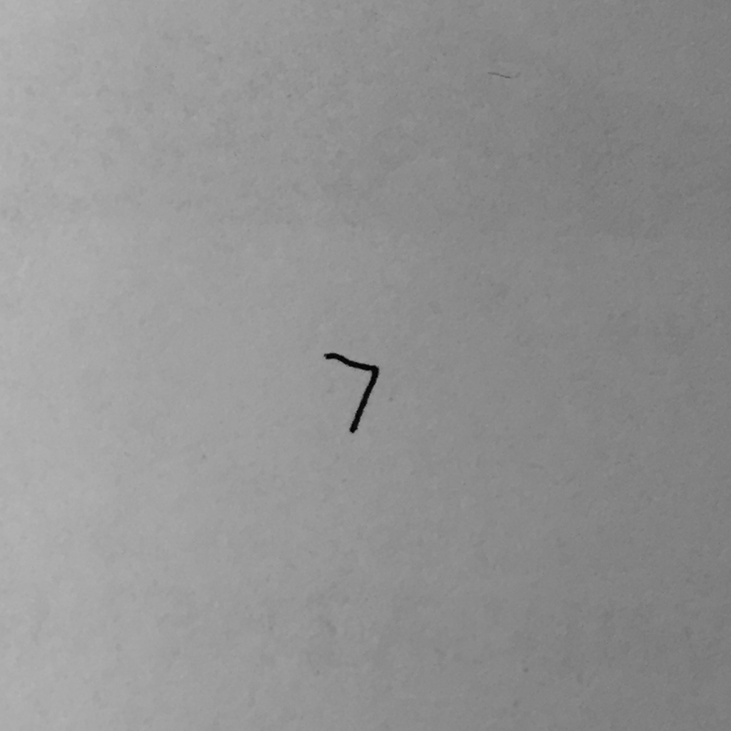

```python
from PIL import Image
display(Image.open("./dataset/c27.gif"))
```

This command changes the image format to the VisionX format and changes it to greyscale.

Then, I used vpix to threshold images and changed them to bilevel images. I chose the threshold value as 75 after some testing. For this process, the pixel would be be 0 when exceeding the threshold. That setting can also give the image light foreground and dark background. The command and result is shown below.

vpix if=c27.vx th=75 hi=0 lo=255 of=c27t.vx

[figure not shown]

```python
display(Image.open("./dataset/c27b.gif"))
```

After that, I wrote a program to find the edge of my hand written character. I checked whether a pixel is 255, and get the longer length as the size of a rectangle. After this step I pass the coordinate of left bottom point and the top right bottom of that rectangle and I cut the rest of the background using vclip.

boundary if=.c27t.vx | xargs vclip if=c27t.vx of=c27b.vx;

Then, I used command to rescale bounding box of c27b and then I used vimag to rescale the image to 20*20. The command and result is shown below.

vibbox if=c27b.vx -xy of=c27bb.vx;

vimag if=c27bb.vx s=20,20,1 of=c27s.vx;

```python
display(Image.open("./dataset/c27s.gif"))
```

[output not shown]

In this step, I wrote a program to find the COM of my character in size 20*20 and reposition it in to 28*28. My command and result is shown below.

size28 if=c27s.vx of=c27ss.vx;

```python
display(Image.open("./dataset/c27ss.gif"))
```

[output not shown]

Finally, I convert VisionX file to the .png file.

vxport if=c27ss.vx -png of=c27;

For my convenience, I wrote a script to process those pictures that I took from the paper and make my own dataset. The script is shown below.

```python
# !/bin/sh
#
for i in {0..59..1}
do
vfmt -g if=./dataset/c$i.JPG of=./dataset/c$i.vx;
vpix if=./dataset/c$i.vx th=75 hi=0 lo=255 of=./dataset/c$(printf "%dt" "$i").vx;
boundary if=./dataset/c$(printf "%dt" "$i").vx | xargs vclip if=./dataset/c$(printf "%dt" "$i").vx of=./dataset/c$(printf "%db" "$i").vx;
vibbox if=./dataset/c${i}b.vx -xy of=./dataset/c${i}bb.vx;
vimag if=./dataset/c${i}bb.vx s=20,20,1 of=./dataset/c${i}s.vx;
size28 if=./dataset/c${i}s.vx of=./dataset/c${i}ss.vx;
vxport if=./dataset/c${i}ss.vx -png of=./dataset/result/c${i};
done
```

## 2. Experiments with Logistic Regression classifier

```python
#1 import required modules
import time
import io
import matplotlib.pyplot as plt
import numpy as np
from scipy.io.arff import loadarff

from sklearn.datasets import get_data_home
from sklearn.externals.joblib import Memory
from sklearn.linear_model import LogisticRegression
from sklearn.model_selection import train_test_split
from sklearn.preprocessing import StandardScaler
from sklearn.utils import check_random_state
from urllib.request import urlopen
```

```python
#2.  read the NMIST dataset
memory = Memory(get_data_home())
@memory.cache()
def fetch_mnist():
    content = urlopen(
        'https://www.openml.org/data/download/52667/mnist_784.arff').read()
    data, meta = loadarff(io.StringIO(content.decode('utf8')))
    data = data.view([('pixels', '<f8', 784), ('class', '|S1')])
    return data['pixels'], data['class']
X, y = fetch_mnist()
```

```python
# rescale the data, use the traditional train/test split

X = X / 255.

###### NEW  Refromat the the labels to be integers rather than byte arrays
y_trans = []
for i in range(len(y)):
    y_trans.append(int(y[i]))
y = np.asarray(y_trans)

X_train, X_test = X[:60000], X[60000:]
y_train, y_test = y[:60000], y[60000:]
```

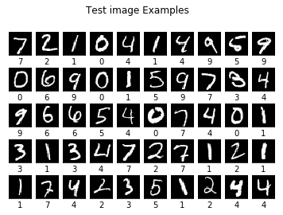

```python
### Bounus 1: show the first ten images
### ALways a good idea to validate that the data appears as you expect
###
### for sci-kit learn the images are represented as vectors of 784 elements
### currently scaled from 0 to 1

for i in range(50):
    l1_plot = plt.subplot(5, 10, i + 1)
    l1_plot.imshow(255 * X_test[i].reshape(28, 28), interpolation='nearest',
                   cmap=plt.cm.gray)
    l1_plot.set_xticks(())
    l1_plot.set_yticks(())
    #l1_plot.set_xlabel('Class %s' % y_test[i].decode())
    l1_plot.set_xlabel('%i' % int(y_test[i]))
plt.suptitle('Test image Examples')
plt.show()
```

```python
## for this demonstration each pixel scale is normalized
## by the mean and standared deviation of the training set
## note the mean and stadard deviation are set by the
## taining set only.
## why is this done?
scaler = StandardScaler()
X_train = scaler.fit_transform(X_train)
X_test = scaler.transform(X_test)
```

```python
#train and test classifier
# Turn up tolerance for faster convergence
clf = LogisticRegression(C=50. / 1000,
                         multi_class='multinomial',
                         penalty='l1', solver='saga', tol=0.1)
# Train the classifier
clf.fit(X_train, y_train)

#Evaluate the classifier
sparsity = np.mean(clf.coef_ == 0) * 100
score = clf.score(X_test, y_test)
# print('Best C % .4f' % clf.C_)
print("Sparsity with L1 penalty: %.2f%%" % sparsity)
print("Test score with L1 penalty: %.4f" % score)
```

```
Sparsity with L1 penalty: 17.68%
Test score with L1 penalty: 0.9027
```

```python
## For analysis show also the confusion matrix

from sklearn.metrics import confusion_matrix
y_predict = clf.predict(X_test)
cfm = confusion_matrix(y_test, y_predict)
print (cfm)
```

```
[[ 958    0    1    1    0    8    8    2    2    0]
 [   0 1103    3    3    1    2    4    0   19    0]
 [  15   16  889   23   15    0   12   22   36    4]
 [   5    4   20  903    1   31    5   17   17    7]
 [   2    7    4    0  915    2   12    2    4   34]
 [  14    4    4   38   17  747   20   15   26    7]
 [  15    6    8    0   11   19  895    1    3    0]
 [   1   24   19    5   11    0    1  930    1   36]
 [  11   20    9   25   20   35   11   17  811   15]
 [  16    8    4   13   52    8    0   28    4  876]]
```

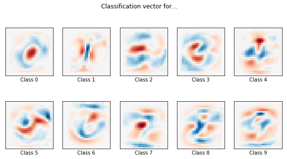

```python
# Bonus 2: Visualization of the weights
# This is only possible for simple classifiers

coef = clf.coef_.copy()
plt.figure(figsize=(10, 5))
scale = np.abs(coef).max()
for i in range(10):
    l1_plot = plt.subplot(2, 5, i + 1)
    l1_plot.imshow(coef[i].reshape(28, 28), interpolation='nearest',
                   cmap=plt.cm.RdBu, vmin=-scale, vmax=scale)
    l1_plot.set_xticks(())
    l1_plot.set_yticks(())
    l1_plot.set_xlabel('Class %i' % i)
plt.suptitle('Classification vector for...')
plt.show()
```

```python
### Bonus 3: comfusion matrix visualization tool
## A more elegant preserntation for a confusion matrix

import itertools
def plot_confusion_matrix(cm, classes,
                          normalize=False,
                          title='Confusion matrix',
                          cmap=plt.cm.Blues):
    """
    This function prints and plots the confusion matrix.
    Normalization can be applied by setting `normalize=True`.
    """
    if normalize:
        cm = cm.astype('float') / cm.sum(axis=1)[:, np.newaxis]
        print("Normalized confusion matrix")
    else:
        print('Confusion matrix, without normalization')

    #print(cm)

    plt.imshow(cm, interpolation='nearest', cmap=cmap)
    plt.title(title)
    plt.colorbar()
    tick_marks = np.arange(len(classes))
    plt.xticks(tick_marks, classes, rotation=45)
    plt.yticks(tick_marks, classes)

    fmt = '.2f' if normalize else 'd'
    thresh = cm.max() / 2.
    for i, j in itertools.product(range(cm.shape[0]), range(cm.shape[1])):
        plt.text(j, i, format(cm[i, j], fmt),
                 horizontalalignment="center",
                 color="white" if cm[i, j] > thresh else "black")

    plt.ylabel('True label')
    plt.xlabel('Predicted label')
    plt.tight_layout()
```

```
Confusion matrix, without normalization
```

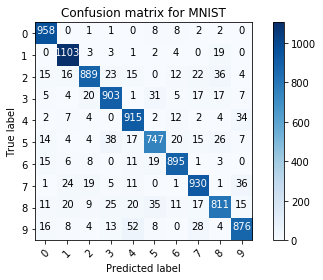

```python
plot_confusion_matrix(cfm, classes=range(10),
                      title='Confusion matrix for MNIST')
```

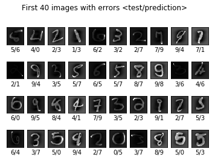

```python
n=0;
i=0;
while n < 40:
    if (y_test[i]!=y_predict[i]):
        l2_plot = plt.subplot(4, 10, n + 1)
        l2_plot.imshow(255 * X_test[i].reshape(28, 28), interpolation='nearest',cmap=plt.cm.gray)
        l2_plot.set_xticks(())
        l2_plot.set_yticks(())
        l2_plot.set_xlabel('%i/%i' % (int(y_test[i]),int(y_predict[i])))
        n+=1
    i+=1
plt.suptitle('First 40 images with errors <test/prediction>')
plt.show()
```

```python
""" Custom datatset loader
    based on https://github.com/utkuozbulak/pytorch-custom-dataset-examples
"""
import pandas as pd
import imageio

class SimpleDataset():
    def __init__(self, data_path, csv_name, transform = None ):
        """
        Args:
            data_path (string): path to the folder where images and csv files are located
            csv_name (string): name of the csv lablel file
            transform: pytorch transforms for transforms and tensor conversion
        """
        # Set path
        self.data_path = data_path
        # Read the csv file
        self.data_info = pd.read_csv(data_path + csv_name, header=None)
        # First column contains the image paths
        self.image_arr = np.asarray(self.data_info.iloc[:, 0])
        # Second column is the labels
        self.label_arr = np.asarray(self.data_info.iloc[:, 1])
        # Calculate len
        self.data_len = len(self.data_info.index)

    def __getitem__(self, index):
        # Get image name from the pandas df
        single_image_name = self.image_arr[index]
        # Open image
        img_as_img = imageio.imread(self.data_path + single_image_name)

        # Get label(class) of the image based on the cropped pandas column
        single_image_label = self.label_arr[index]

        return (img_as_img, single_image_label)

    def __len__(self):
        return self.data_len
```

```python
mydata = SimpleDataset( "./dataset/result/", "labels1.csv")

#splitting into images and labels
X = []
y = []
for i in range(len(mydata)):
    X.append(mydata[i][0])
    y.append((mydata[i][1]))

#converting into numpy arrays to enable easy reshaping and other array operations

X = np.asarray(X)
print("Shape of the input image", X.shape)
y= np.asarray(y)
```

```
Shape of the input image (60, 28, 28)
```

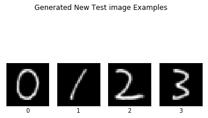

```python
import warnings
warnings.filterwarnings('ignore')
#l1_plot = plt.subplot(1, 4, i + 1)
for i in range(4):
    l1_plot = plt.subplot(1, 4, i + 1)
    l1_plot.imshow(X[i], interpolation='nearest',
                   cmap=plt.cm.gray)
    l1_plot.set_xticks(())
    l1_plot.set_yticks(())
    l1_plot.set_xlabel('%i' % int(y[i]))
plt.suptitle('Generated New Test image Examples')
plt.show()
```

```python
#reshaping the array into flattened 784 array as an input for prediciton by the logistic regression classifier
X = X.reshape(X.shape[0], 784)
X = X / 255.
#data standardiation with the training set statistics is required for this clasifier
X = scaler.transform(X)

y_pred = clf.predict(X)

score = clf.score(X, y)

print("Test score with L1 penalty: %.4f" % score)
print("y_predicted_values", y_pred)
print("y_labels", y)
```

```
Test score with L1 penalty: 0.4500
y_predicted_values [0 1 3 3 1 5 6 2 4 1 0 1 2 3 4 5 5 1 3 4 0 1 2 3 1 5 5 3 8 7 0 1 1 5 1 1 6
 1 8 7 0 1 2 3 1 5 6 2 3 1 4 1 5 1 1 1 4 1 5 4]
y_labels [ 0  1  2  3  4  5  6  7  8  9  0  1  2  3  4  5  6  7  8  9  0  1  2  3
  4  5  6  7  8  9  0  1  2  3  4  5  6  7  8  9  0  1  2  3  4  5  6  7
  8  9 10 11 12 13 14 15 16 17 18 19]
```

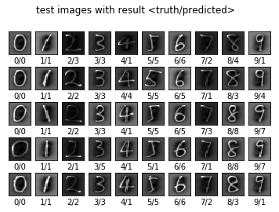

```python
import warnings
warnings.filterwarnings('ignore')
#l1_plot = plt.subplot(1, 4, i + 1)
for i in range(50):
    l1_plot = plt.subplot(5, 10, i + 1)
    l1_plot.imshow(X[i].reshape(28,28), interpolation='nearest',
                    cmap=plt.cm.gray)
    l1_plot.set_xticks(())
    l1_plot.set_yticks(())
    l1_plot.set_xlabel('%i/%i' % (int(y[i]),int(y_pred[i])))
plt.suptitle('test images with result <truth/predicted>')
plt.show()
```

### 3. Plot all your test images with truth and predicted labels. Discuss these results.

For my own dataset, the digit 0 and 1 is all correct. The prediction for 2,3,5,6 have high accuracy. However, the digit 4 is recognized as 1 and there are various results for digit 7, 8 and 9. We can tell that the accuracy is relatively low for my own dataset.